# Introduction to Mixture Models - Latent Class Analysis

Labs created by Adam Garber and Dina Arch

Updated: October 15, 2024

`University of California, Santa Barbara`

Load packages

```r
library(tidyverse)
library(haven)
library(glue)
library(MplusAutomation)
library(rhdf5)
library(here)
library(janitor)
library(gt)
library(semPlot)
library(reshape2)
library(cowplot)
library(filesstrings)
library(hrbrthemes)
library(poLCA)
here::i_am("intro_to_lca.Rmd")
```

## Example: Undergraduate Cheating behavior

“Dichotomous self-report responses by 319 undergraduates to four questions about cheating behavior” (poLCA, 2016).

*Data source*: This example utilizes a dataset on undergraduate *Cheating* available from the `poLCA` package (Dayton, 1998): [See documentation here](https://cran.r-project.org/web/packages/poLCA/poLCA.pdf)

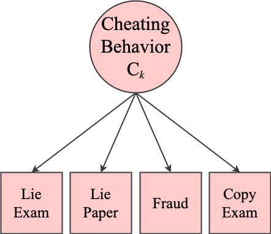

LCA indicators<sup>1</sup>

| Name | Label | Values |
| --- | --- | --- |
| LieExam | lied to avoid taking an exam | 0 = No, 1 = Yes |
| LiePaper | lied to avoid handing a term paper in on time | 0 = No, 1 = Yes |
| Fraud | purchased a term paper to hand in as their own or had obtained a copy of an exam prior to taking the exam | 0 = No, 1 = Yes |
| CopyExam | copied answers during an exam from someone sitting near to them | 0 = No, 1 = Yes |

<sup>1</sup> Undergraduate Cheating Behavior

### Prepare Data

```r
data(cheating)

df_cheat <-  cheating %>%
  clean_names() %>%
  dplyr::select(1:4) %>%
  dplyr::mutate_all(funs(.-1)) # Subtracts one from all variables (so that 0=No and 1=Yes)
```

### Descriptive Statistics

```r
ds <- df_cheat %>%
  pivot_longer(lieexam:copyexam, names_to = "variable") %>%
  group_by(variable) %>%
  summarise(prop = sum(value)/n(),
            n = n()) %>%
  arrange(desc(prop))

prop_table <- ds %>%
  gt () %>%
  tab_header(title = md("**Descriptive Summary**")) %>%
  cols_label(
    variable = "Variable",
    n = md("*N*"),
    prop = md("Proportion Endorsed")
  ) %>%
  fmt_number(c(2),
             decimals = 2) %>%
  cols_align(
    align = "center",
    columns = prop
  )

prop_table
```

**Descriptive Summary**

| Variable | Proportion Endorsed | *N* |
| --- | --- | --- |
| copyexam | 0.21 | 319 |
| liepaper | 0.12 | 319 |
| lieexam | 0.11 | 319 |
| fraud | 0.07 | 319 |

```r
# Save as a Word doc
gtsave(prop_table, here("figures", "prop_table.docx"))
```

### Enumeration

This code uses the `mplusObject` function in the `MplusAutomation` package.

```r
lca_cheat_6  <- lapply(1:6, function(k) {
  lca_enum  <- mplusObject(

    TITLE = glue("{k}-Class"),

    VARIABLE = glue(
    "categorical = lieexam-copyexam;
     usevar = lieexam-copyexam;
     classes = c({k}); "),

  ANALYSIS =
   "estimator = mlr;
    type = mixture;
    starts = 200 100;
    processors = 10;",

  OUTPUT = "sampstat residual tech11 tech14 svalues;",

  PLOT =
    "type = plot3;
    series = lieexam-copyexam(*);",

  usevariables = colnames(df_cheat),
  rdata = df_cheat)

lca_enum_fit <- mplusModeler(lca_enum,
                            dataout=glue(here("enum_mplus", "cheat_Lab3.dat")),
                            modelout=glue(here("enum_mplus", "c{k}_cheat_Lab3.inp")) ,
                            check=TRUE, run = TRUE, hashfilename = FALSE)
})
```

### Table of Fit

First, extract data:

```r
output_cheat <- readModels(here("enum_mplus"), filefilter = "cheat", quiet = TRUE)

enum_extract <- LatexSummaryTable(
  output_cheat,
  keepCols = c(
    "Title",
    "Parameters",
    "LL",
    "BIC",
    "aBIC",
    "BLRT_PValue",
    "T11_VLMR_PValue",
    "Observations"
  ),
  sortBy = "Title"
)


allFit <- enum_extract %>%
  mutate(CAIC = -2 * LL + Parameters * (log(Observations) + 1)) %>%
  mutate(AWE = -2 * LL + 2 * Parameters * (log(Observations) + 1.5)) %>%
  mutate(SIC = -.5 * BIC) %>%
  mutate(expSIC = exp(SIC - max(SIC))) %>%
  mutate(BF = exp(SIC - lead(SIC))) %>%
  mutate(cmPk = expSIC / sum(expSIC)) %>%
  dplyr::select(1:5, 9:10, 6:7, 13, 14) %>%
  arrange(Parameters)
```

Then, create table:

```r
fit_table1 <- allFit %>%
  gt() %>%
  tab_header(title = md("**Model Fit Summary Table**")) %>%
  cols_label(
    Title = "Classes",
    Parameters = md("Par"),
    LL = md("*LL*"),
    T11_VLMR_PValue = "VLMR",
    BLRT_PValue = "BLRT",
    BF = md("BF"),
    cmPk = md("*cmPk*")
  ) %>%
  tab_footnote(
    footnote = md(
      "*Note.* Par = Parameters; *LL* = model log likelihood;
BIC = Bayesian information criterion;
aBIC = sample size adjusted BIC; CAIC = consistent Akaike information criterion;
AWE = approximate weight of evidence criterion;
BLRT = bootstrapped likelihood ratio test p-value;
VLMR = Vuong-Lo-Mendell-Rubin adjusted likelihood ratio test p-value;
*cmPk* = approximate correct model probability."
    ),
locations = cells_title()
  ) %>%
  tab_options(column_labels.font.weight = "bold") %>%
  fmt_number(c(3:7),
             decimals = 2) %>%
  fmt_missing(1:11,
              missing_text = "--") %>%
  fmt(
    c(8:9, 11),
    fns = function(x)
      ifelse(x < 0.001, "<.001",
             scales::number(x, accuracy = .01))
  ) %>%
  fmt(
    10,
    fns = function (x)
      ifelse(x > 100, ">100",
             scales::number(x, accuracy = .01))
  ) %>%
  tab_style(
    style = list(
      cell_text(weight = "bold")
      ),
    locations = list(cells_body(
     columns = BIC,
     row = BIC == min(BIC[c(1:6)]) # Change this to the number of classes you estimated
    ),
    cells_body(
     columns = aBIC,
     row = aBIC == min(aBIC[1:6])
    ),
    cells_body(
     columns = CAIC,
     row = CAIC == min(CAIC[1:6])
    ),
    cells_body(
     columns = AWE,
     row = AWE == min(AWE[1:6])
    ),
    cells_body(
     columns = cmPk,
     row =  cmPk == max(cmPk[1:6])
     ),
    cells_body(
     columns = BF,
     row =  BF > 10),
    cells_body(
     columns =  T11_VLMR_PValue,
     row =  ifelse(T11_VLMR_PValue < .001 & lead(T11_VLMR_PValue) > .05, T11_VLMR_PValue < .001, NA)),
    cells_body(
     columns =  BLRT_PValue,
     row =  ifelse(BLRT_PValue < .001 & lead(BLRT_PValue) > .05, BLRT_PValue < .001, NA))
  )
)

fit_table1
```

**Model Fit Summary Table**<sup>1</sup>

| Classes | Par | *LL* | BIC | aBIC | CAIC | AWE | BLRT | VLMR | BF | *cmPk* |
| --- | --- | --- | --- | --- | --- | --- | --- | --- | --- | --- |
| 1-Class | 4 | −467.44 | 957.94 | 945.25 | 961.94 | 993.00 | – | – | 0.00 | <.001 |
| 2-Class | 9 | −440.03 | 931.94 | 903.39 | 940.94 | 1,010.83 | <.001 | <.001 | >100 | 1.00 |
| 3-Class | 14 | −436.24 | 953.18 | 908.78 | 967.18 | 1,075.90 | 0.14 | 0.17 | >100 | <.001 |
| 4-Class | 19 | −436.14 | 981.83 | 921.56 | 1,000.83 | 1,148.37 | 1.00 | 0.69 | >100 | <.001 |
| 5-Class | 24 | −436.14 | 1,010.65 | 934.53 | 1,034.65 | 1,221.02 | 1.00 | 0.05 | >100 | <.001 |
| 6-Class | 29 | −436.14 | 1,039.48 | 947.50 | 1,068.48 | 1,293.67 | 1.00 | 0.43 | – | <.001 |

<sup>1</sup> *Note.* Par = Parameters; *LL* = model log likelihood; BIC = Bayesian information criterion; aBIC = sample size adjusted BIC; CAIC = consistent Akaike information criterion; AWE = approximate weight of evidence criterion; BLRT = bootstrapped likelihood ratio test p-value; VLMR = Vuong-Lo-Mendell-Rubin adjusted likelihood ratio test p-value; *cmPk* = approximate correct model probability.

Save table:

```r
gtsave(fit_table1, here("figures", "fit_table1.png"))
```

Enumeration Table Shortcut (*optional*)

```r
source("enum_table.txt")

output_cheat <- readModels(here("enum_mplus"), filefilter = "cheat", quiet = TRUE)

# To see rows:
seeRows(output_cheat)

# Arguments for `enum_table`
# 1. readModels objects
# 2-5. Rows of successfully estimated models
enum_table(output_cheat, 1:6)
```

### Information Criteria Plot

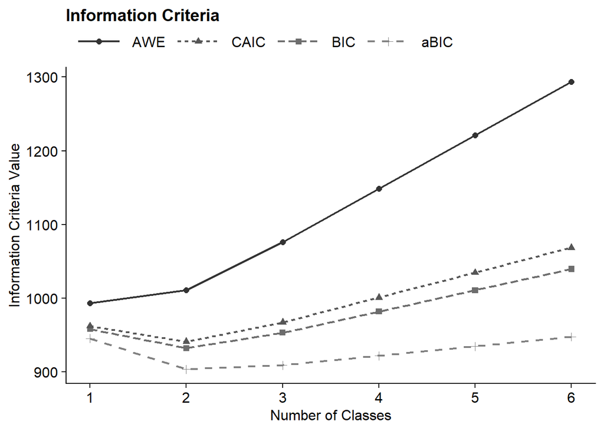

```r
allFit %>%
  dplyr::select(2:7) %>%
  rowid_to_column() %>%
  pivot_longer(`BIC`:`AWE`,
               names_to = "Index",
               values_to = "ic_value") %>%
  mutate(Index = factor(Index,
                        levels = c ("AWE", "CAIC", "BIC", "aBIC"))) %>%
  ggplot(aes(
    x = rowid,
    y = ic_value,
    color = Index,
    shape = Index,
    group = Index,
    lty = Index
  )) +
  geom_point(size = 2.0) + geom_line(size = .8) +
  scale_x_continuous(breaks = 1:nrow(allFit)) +
  scale_colour_grey(end = .5) +
  theme_cowplot() +
  labs(x = "Number of Classes", y = "Information Criteria Value", title = "Information Criteria") +
  theme(
    text = element_text(family = "Times", size = 12),
    legend.text = element_text(family="Times", size=12),
    legend.key.width = unit(3, "line"),
    legend.title = element_blank(),
    legend.position = "top"
  )
```

Save figure:

```r
ggsave(here("figures", "info_criteria.png"), dpi=300, height=5, width=7, units="in")
```

### Compare Class Solutions

Compare probability plots for $K = 1:6$ class solutions

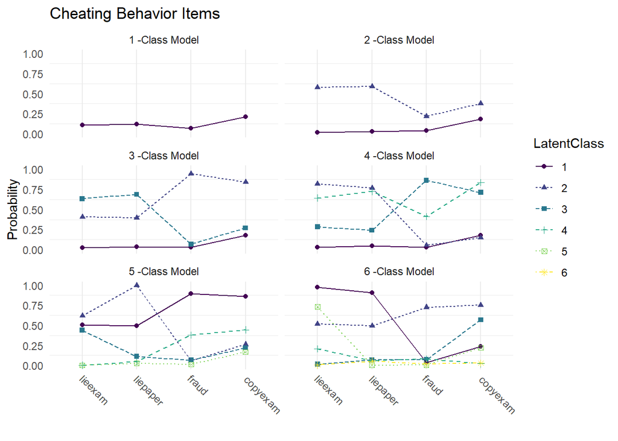

```r
model_results <- data.frame()

for (i in 1:length(output_cheat)) {

  temp <- output_cheat[[i]]$parameters$probability.scale %>%
    mutate(model = paste(i,"-Class Model"))

  model_results <- rbind(model_results, temp)
}

rm(temp)

compare_plot <-
  model_results %>%
  filter(category == 2) %>%
  dplyr::select(est, model, LatentClass, param) %>%
  mutate(param = as.factor(str_to_lower(param)))

compare_plot$param <- fct_inorder(compare_plot$param)

ggplot(
  compare_plot,
  aes(
    x = param,
    y = est,
    color = LatentClass,
    shape = LatentClass,
    group = LatentClass,
    lty = LatentClass
  )
) +
  geom_point() +
  geom_line() +
  scale_colour_viridis_d() +
  facet_wrap( ~ model, ncol = 2) +
  labs(title = "Cheating Behavior Items",
       x = " ", y = "Probability") +
  theme_minimal() +
  theme(panel.grid.major.y = element_blank(),
                          axis.text.x = element_text(angle = -45, hjust = -.1))
```

Save figure:

```r
ggsave(here("figures", "compare_kclass_plot.png"), dpi=300, height=5, width=7, units="in")
```

### 2-Class Probability Plot

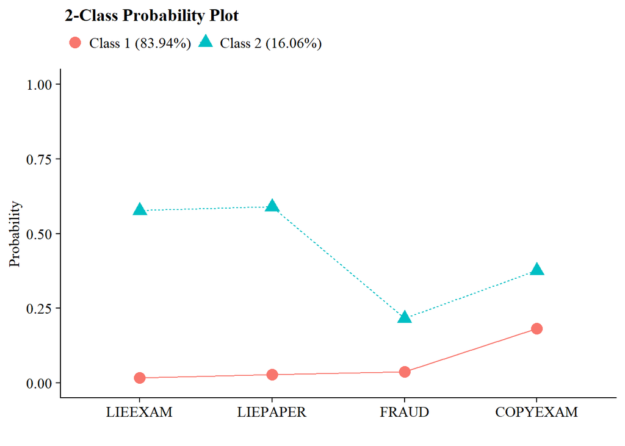

```r
source("plot_lca.txt")

plot_lca(model_name = output_cheat$c2_cheat_lab3.out)
```

Save figure:

```r
ggsave(here("figures", "C2_Cheat_LCA_Plot.png"), dpi="retina", height=5, width=7, units="in")
```

### Observed Response Patterns

Note the optseed here!

```r
patterns  <- mplusObject(

  TITLE = "LCA - Save response patterns",

  VARIABLE =
  "categorical = lieexam-copyexam;
   usevar =  lieexam-copyexam;
   classes = c(2);",

  ANALYSIS =
   "estimator = mlr;
    type = mixture;
    starts = 0;
    processors = 10;
    optseed = 887676;",

  SAVEDATA =
   "File=savedata.dat;
    Save=cprob;

    ! Code to save response frequency data

    response is resp_patterns.dat;",

  OUTPUT = "patterns tech10 tech11 tech14",

  usevariables = colnames(df_cheat),
  rdata = df_cheat)

patterns_fit <- mplusModeler(patterns,
                dataout=here("mplus", "patterns.dat"),
                modelout=here("mplus", "patterns.inp") ,
                check=TRUE, run = TRUE, hashfilename = FALSE)
```

Read in observed response pattern data and relabel the columns

```r
# Read in response frequency data that we just created:
patterns <- read_table(here("mplus", "resp_patterns.dat"),
                        col_names=FALSE, na = "*")

# Extract the column names
names <- names(readModels(here("mplus", "patterns.out"))[['savedata']])

# Add the names back to the dataset
colnames(patterns) <- c("Frequency", names)
```

Create a table with the top 5 unconditional response pattern, then top of conditional response pattern for each modal class assignment

```r
# Order responses by highest frequency
order_highest <- patterns %>%
  arrange(desc(Frequency))

# Loop `patterns` data to list top 5 conditional response patterns for each class
loop_cond  <- lapply(1:max(patterns$C), function(k) {
order_cond <- patterns %>%
  filter(C == k) %>%
  arrange(desc(Frequency)) %>%
  head(5)
  })

# Convert loop into data frame
table_data <- as.data.frame(bind_rows(loop_cond))

# Combine unconditional and conditional responses patterns
response_patterns <-  rbind(order_highest[1:5,], table_data)
```

Finally, use `{gt}` to make a nicely formatted table

Note: In this example, there are only four response patterns for Class 1.

```r
resp_table <- response_patterns %>%
  gt() %>%
    tab_header(
    title = "Observed Response Patterns",
    subtitle = html("Response patterns, estimated frequencies, estimated posterior class probabilities and modal assignments")) %>%
    tab_source_note(
    source_note = md("Data Source: **Cheating Data**")) %>%
    cols_label(
      Frequency = html("<i>f</i><sub>r</sub>"),
    LIEEXAM = "Lie on Exam",
    LIEPAPER = "Lie on Paper",
    FRAUD = "Fraud",
    COPYEXAM = "Copy Exam",
    CPROB1 = html("P<sub><i>k</i></sub>=1"),
    CPROB2 = html("P<sub><i>k</i></sub>=2"),   # Change based on number of classes
    C = md("*k*")) %>%
  tab_row_group(
    label = "Unconditional response patterns",
    rows = 1:5) %>%
  tab_row_group(
    label = md("*k* = 1 Conditional response patterns"),
    rows = 6:9) %>% #EDIT THESE VALUES BASED ON THE LAST COLUMN
  tab_row_group(
    label = md("*k* = 2 Conditional response patterns"),
    rows = 10:14)  %>% #EDIT THESE VALUES BASED ON THE LAST COLUMN
    row_group_order(
      groups = c("Unconditional response patterns",
                 md("*k* = 1 Conditional response patterns"),
                 md("*k* = 2 Conditional response patterns"))) %>%
    tab_footnote(
    footnote = html(
      "<i>Note.</i> <i>f</i><sub>r</sub> = response pattern frequency; P<sub><i>k</i></sub> = posterior class probabilities"
    )
  ) %>%
  cols_align(align = "center") %>%
  opt_align_table_header(align = "left") %>%
  gt::tab_options(table.font.names = "Times New Roman")

resp_table
```

Observed Response Patterns

Response patterns, estimated frequencies, estimated posterior class probabilities and modal assignments

| *f*<sub>r</sub> | Lie on Exam | Lie on Paper | Fraud | Copy Exam | P<sub>*k*</sub>=1 | P<sub>*k*</sub>=2 | *k* |
| --- | --- | --- | --- | --- | --- | --- | --- |
| Unconditional response patterns |  |  |  |  |  |  |  |
| 207 | 0 | 0 | 0 | 0 | 0.979 | 0.021 | 1 |
| 46 | 0 | 0 | 0 | 1 | 0.945 | 0.055 | 1 |
| 13 | 0 | 1 | 0 | 0 | 0.493 | 0.507 | 2 |
| 11 | 1 | 1 | 0 | 0 | 0.012 | 0.988 | 2 |
| 10 | 1 | 0 | 0 | 0 | 0.364 | 0.636 | 2 |
| *k* = 1 Conditional response patterns |  |  |  |  |  |  |  |
| 207 | 0 | 0 | 0 | 0 | 0.979 | 0.021 | 1 |
| 46 | 0 | 0 | 0 | 1 | 0.945 | 0.055 | 1 |
| 7 | 0 | 0 | 1 | 0 | 0.866 | 0.134 | 1 |
| 5 | 0 | 0 | 1 | 1 | 0.704 | 0.296 | 1 |
| *k* = 2 Conditional response patterns |  |  |  |  |  |  |  |
| 13 | 0 | 1 | 0 | 0 | 0.493 | 0.507 | 2 |
| 11 | 1 | 1 | 0 | 0 | 0.012 | 0.988 | 2 |
| 10 | 1 | 0 | 0 | 0 | 0.364 | 0.636 | 2 |
| 4 | 0 | 1 | 0 | 1 | 0.264 | 0.736 | 2 |
| 4 | 1 | 1 | 0 | 1 | 0.004 | 0.996 | 2 |

Data Source: **Cheating Data**  
*Note.* *f*<sub>r</sub> = response pattern frequency; P<sub>*k*</sub> = posterior class probabilities

Save table:

```r
gtsave(resp_table, here("figures","resp_table.docx"))
```

### Classification Diagnostics

Use Mplus to calculate k-class confidence intervals (Note: Change the syntax to make your chosen *k*-class model):

Note: We chose the two-class model, but I am looking at the classification diagnostics for the four-class model to get an idea of how the model is specified (as the two-class model syntax is too simplisitc)

```r
classification  <- mplusObject(

  TITLE = "LCA - Calculated k-Class 95% CI",

  VARIABLE =
  "categorical = lieexam-copyexam;
   usevar =  lieexam-copyexam;
   classes = c(4);",

  ANALYSIS =
   "estimator = ml;
    type = mixture;
    starts = 0;
    processors = 10;
    optseed = 417035;
    bootstrap = 1000;",

  MODEL =
    "
  !CHANGE THIS SECTION TO YOUR CHOSEN k-CLASS MODEL

  %OVERALL%
  [C#1](c1);
  [C#2](c2);
  [C#3](c3);

  Model Constraint:
  New(p1 p2 p3 p4);

  p1 = exp(c1)/(1+exp(c1)+exp(c2)+exp(c3));
  p2 = exp(c2)/(1+exp(c1)+exp(c2)+exp(c3));
  p3 = exp(c3)/(1+exp(c1)+exp(c2)+exp(c3));
  p4 = 1/(1+exp(c1)+exp(c2)+exp(c3));",


  OUTPUT = "cinterval(bcbootstrap)",

  usevariables = colnames(df_cheat),
  rdata = df_cheat)

classification_fit <- mplusModeler(classification,
                dataout=here("mplus", "class.dat"),
                modelout=here("mplus", "class.inp") ,
                check=TRUE, run = TRUE, hashfilename = FALSE)
```

*Note*: Ensure that the classes did not shift during this step (i.g., Class 1 in the enumeration run is now Class 4). Evaluate output and compare the class counts and proportions for the latent classes. Using the OPTSEED function ensures replication of the best loglikelihood value run.

Read in the 4-class model:

```r
# Read in the 4-class model and extract information needed
class_output <- readModels(here("mplus", "class.out"))

# Entropy
entropy <- c(class_output$summaries$Entropy, rep(NA, class_output$summaries$NLatentClasses-1))

# 95% k-Class and k-class 95% Confidence Intervals
k_ci <- class_output$parameters$ci.unstandardized %>%
  filter(paramHeader == "New.Additional.Parameters") %>%
  unite(CI, c(low2.5,up2.5), sep=", ", remove = TRUE) %>%
  mutate(CI = paste0("[", CI, "]")) %>%
  rename(kclass=est) %>%
  dplyr::select(kclass, CI)

# AvePPk = Average Latent Class Probabilities for Most Likely Latent Class Membership (Row) by Latent Class (Column)
avePPk <- tibble(avePPk = diag(class_output$class_counts$avgProbs.mostLikely))

# mcaPk = modal class assignment proportion
mcaPk <- round(class_output$class_counts$mostLikely,3) %>%
  mutate(model = paste0("Class ", class)) %>%
  add_column(avePPk, k_ci) %>%
  rename(mcaPk = proportion) %>%
  dplyr::select(model, kclass, CI, mcaPk, avePPk)

# OCCk = odds of correct classification
OCCk <- mcaPk %>%
  mutate(OCCk = round((avePPk/(1-avePPk))/(kclass/(1-kclass)),3))

# Put everything together
class_df <- data.frame(OCCk)
```

Now, use `{gt}` to make a nicely formatted table

```r
class_table <- class_df %>%
  gt() %>%
    tab_header(
    title = "Model Classification Diagnostics for the 4-Class Solution") %>%
    cols_label(
      model = md("*k*-Class"),
      kclass = md("*k*-Class Proportions"),
      CI = "95% CI",
      mcaPk = md("*mcaPk*"),
      avePPk = md("*AvePPk*"),
      OCCk = md("*OCCk*")) %>%
    sub_missing(6,
              missing_text = "") %>%
  cols_align(align = "center") %>%
  opt_align_table_header(align = "left") %>%
  gt::tab_options(table.font.names = "Times New Roman")

class_table
```

Model Classification Diagnostics for the 4-Class Solution

| *k*-Class | *k*-Class Proportions | 95% CI | *mcaPk* | *AvePPk* | *OCCk* |
| --- | --- | --- | --- | --- | --- |
| Class 1 | 0.876 | [0.815, 0.943] | 0.909 | 0.956 | 3.076 |
| Class 2 | 0.063 | [0.009, 0.172] | 0.038 | 0.896 | 128.137 |
| Class 3 | 0.033 | [0.008, 0.123] | 0.034 | 0.633 | 50.542 |
| Class 4 | 0.029 | [0.006, 0.09] | 0.019 | 0.594 | 48.987 |

Save table:

```r
gtsave(class_table, here("figures","class_table.docx"))
```

## References

Drew A. Linzer, Jeffrey B. Lewis (2011). poLCA: An R Package for Polytomous Variable Latent Class Analysis. Journal of Statistical Software, 42(10), 1-29. URL http://www.jstatsoft.org/v42/i10/.

Hallquist, M. N., & Wiley, J. F. (2018). MplusAutomation: An R Package for Facilitating Large-Scale Latent Variable Analyses in Mplus. Structural equation modeling: a multidisciplinary journal, 25(4), 621-638.

Muthén, B. O., Muthén, L. K., & Asparouhov, T. (2017). Regression and mediation analysis using Mplus. Los Angeles, CA: Muthén & Muthén.

Muthén, L.K. and Muthén, B.O. (1998-2017). Mplus User’s Guide. Eighth Edition. Los Angeles, CA: Muthén & Muthén

R Core Team (2017). R: A language and environment for statistical computing. R Foundation for Statistical Computing, Vienna, Austria. URL http://www.R-project.org/

Wickham et al., (2019). Welcome to the tidyverse. Journal of Open Source Software, 4(43), 1686, https://doi.org/10.21105/joss.01686